# Interprétations et éxplications de l’ACP

Chiara Coppa

12/6/2022

# Introduction

L’analyse en composantes principales (ACP) est une méthode statistique qui permet de réduire le nombre de variables qui décrivent une certaine région en quelques composantes principales sans perdre trop d’informations. Elle permet donc de réduire la dimensionnalité, donc le nombre de variables, pour en extraire les principales qui peuvent décrire l’ensemble de la région.

Pour commencer, j’ai créé un tableau avec 17 variables qui décrivent les communes des districts de Muri dans le canton d’Argovie et d’Affoltern dans le canton de Zurich. À cause d’un manque de données pour les communes de Hedingen (Affoltern) et Aristau (Muri) j’ai enlevé ces communes de mon analyse. Les variables que j’ai sélectionnées sont les suivantes:

- la proportion de foyer d’une seule personne sur le nombre de ménages
- la proportion d’émigration, calculée en divisant le nombre de personnes émigrées par la population de chaque commune
- la proportion d’immigration, calculée en divisant le nombre de personnes immigrées par la population de chaque commune
- la proportion d’étrangers, calculée en divisant le nombre d’étrangers par la population de chaque commune
- la proportion de Oui à l’initiative populaire du 25.11.2018 «Pour la dignité des animaux de rente agricoles (initiative pour les vaches à cornes)»
- la proportion de surface d’habitat et d’infrastructure, calculée en divisant la surface d’habitat et d’infrastructure par la surface de chaque commune
- la proportion de surface agricole, calculée en divisant la surface agricole par la surface de chaque commune
- la proportion de population entre 0 et 19 ans, calculée en divisant le nombre de personnes de 0 à 19 ans par la population de chaque commune
- la proportion de population entre 20 et 39 ans, calculée en divisant le nombre de personnes de 20 à 39 ans par la population de chaque commune
- la proportion de population entre 40 et 64 ans, calculée en divisant le nombre de personnes de 40 à 64 ans par la population de chaque commune
- la proportion de population de 65 ans et plus, calculée en divisant le nombre de personnes de 65 ans et plus par la population de chaque commune
- la proportion de personnes de sexe masculin employées, calculée en divisant le nombre d’hommes employés par le nombre total des employés pour chaque commune
- la proportion de personnes de sexe féminin employées, calculée en divisant le nombre de femmes employées par le nombre total des employés pour chaque commune
- la proportion du secteur primaire, calculée en divisant le nombre d’emplois dans le secteur primaire par le nombre total d’emplois
- la proportion du secteur secondaire, calculée en divisant le nombre d’emplois dans le secteur secondaire par le nombre total d’emplois
- la proportion du secteur tertiaire, calculée en divisant le nombre d’emplois dans le secteur tertiaire par le nombre total d’emplois
- la proportion de voitures, calculée en divisant le nombre de voitures par la population de chaque commune

J’ai chargé dans R le tableau avec mes variables (à l’aide de la commande read.delim). J’ai vérifié si le chargement s’est déroulé correctement à travers la commande “head” qui montre les premières lignes du tableau. Puis, j’ai contrôlé le nombre de colonnes pour ensuite sélectionner seulement celles qui contenaient les variables pour réaliser l’ACP. Donc j’ai créé un nouveau jeu de données (d_sel) où j’ai sélectionné les colonnes de 2 à 18 (comprises) pour prendre en considération que mes variables (la première colonne, je l’ai enlevé parce qu’elle contenait le nom des communes). J’ai vérifié à travers “head” que l’opération s’est bien passé.

La réduction de la dimensionnalité est plus simple à réaliser si les variables sont corrélées entre elles. Si elles sont plus corrélées cela signifie que c’est plus facile d’enlever des variables parce qu’elles sont déjà représentées par les autres fortement corrélées. On peut donc regarder la matrice des corrélations qui est réalisable à travers la commande “cor”. Vu que le nombre de corrélations est élevé, j’ai mis en évidence la valeur minimale et maximale pour chaque colonne de la matrice de corrélation, en enlevant la corrélation égale à 1 (qui est la corrélation d’une variable avec elle-même). Avec cette opération, j’ai trouvé que plusieurs variables ont une corrélation maximale supérieure à 0.5 (à savoir 10 variables), qui montre donc que mon tableau peut être réduit à des composantes principales. Mon tableau est donc prêt à la réalisation de l’ACP.

# Réalisation de l’ACP

Tout d’abord, pour commencer, j’ai téléchargé les packages qui servent à la réalisation de l’ACP (factoextra, ggpubr, FactoMineR). Après l’installation, j’ai calculé l’ACP avec le code “PCA”, dans lequel j’ai indiqué le nombre de dimensions (ou composantes) à garder dans le résultat. Avec la commande “get_eig” sur le résultat de l’ACP, j’ai visualisé les composantes de l’analyse avec leur valeur propre (eigenvalue), leur variance expliquée (qui montre l’importance de la composante) et leur variance cumulée (qui fait la somme des variances expliquées plus importantes).

Après ça, je dois décider combien de composantes principales je veux garder. Pour le faire, il y a plusieurs méthodes:

- La première méthode est celle de garder les composantes qui ont une valeur propre supérieure à 1. Si j’utilise cette méthode, je trouve qu’il faut garder les 5 premières composantes.
- La deuxième méthode est celle de faire un “scree plot” et garder les composantes jusqu’au coude du graphique. Dans ce cas, le nombre de composantes à retenir est 2.
- La troisième méthode est celle de considérer les composantes jusqu’à celle qui possède comme variance cumulée la valeur de 80%. Dans mon cas, je devrais retenir les 6 premières composantes.

## Optimisation des indicateurs

Comme précisé dans les consignes du travail pratique, je dois optimiser mes indicateurs afin d’avoir pour la première composante une explication d’au moins 50% de la variance et les quatre premières de 85%. Pour le faire, je dois éliminer des indicateurs de mes données initiales en privilégiant ceux qui ne sont pas fortement liées aux premières dimensions, mais qui ont des corrélations plus importantes avec les dimensions supérieures. Les communalités peuvent m’aider dans le choix des indicateurs à éliminer, parce qu’elles montrent la contribution des différentes variables aux composantes principales. Encore plus intéressantes sont les communalités brutes qui montrent la corrélation entre les variables et les composantes principales. En plus, avec “fviz_contrib” je peux réaliser un graphique qui montre pour chaque variable la contribution à une dimension.

Avec ces opérations, j’ai trouvé quelles variables ont une plus grande corrélation avec les composantes supérieures et une faible corrélation avec les premières dimensions. Par exemple, j’ai regardé le graphique gradué des communalités et j’ai constaté que la proportion de population entre 40 et 60 ans est peu lié aux autres variables. Donc j’ai enlevé cette variable. Avec le calcul de la variance expliquée, j’ai vu que la variance cumulée est augmentée, mais pas suffisamment. Je dois donc enlever d’autres variables. J’ai regardé les communalités brutes dans ce cas et j’ai vu que l’indicateur de la proportion d’immigration est peu lié à la première composante (-0,23%) et plus lié à la composante numéro cinq (0,48%). J’ai donc décidé d’éliminer cette variable. Le calcul de la variance me donne une valeur majeure par rapport à avant, mais qui n’est pas encore suffisante. En utilisant le même tableau des corrélation, j’ai décidé d’enlever aussi la proportion du secteur secondaire, selon la même logique. La variance n’a pas encore atteint le 50% donc je dois enlever d’autres variables, comme la proportion d’emplois féminins et masculins qui ont une faible corrélation avec la première composante. Vu que la variance n’a pas encore atteint le 50% j’ai utilisé le graphique “fviz_contrib” pour voir la contribution de chaque variable à la dimension 5. À partir de ce graphique, j’ai identifié comme variables à éliminer celles qui contribuaient plus à la cinquième composante: proportion d’émigration, proportion de voitures, proportion de population entre 0 et 19 ans et proportion d’habitat et infrastructure. À la fin, j’ai obtenu le résultat désiré: la variance expliquée par la première composante est de 50% et la variance cumulée des quatre premières est de 88%.

# Interprétation des composantes

- Le première est expliquée en majorité par la proportion de la surface agricole dans les communes.
- La deuxième s’explique pour plus de la moitié par la proportion de population entre 20 et 39 ans.
- La troisième pour plus de la moitié par la proportion de foyer d’une seule personne.
- La quatrième par la proportion de population de plus de 65 ans.

## Les scores factoriels

Les scores factoriels sont des valeurs qui déterminent la relation entre les communes et les composantes principales. Avec le code “fviz_pca_in”, j’ai obtenu un graphique des communes en fonction des deux premières composantes avec une coloration graduée qui montre la qualité de chaque région en fonction de la dimension. Les scores factoriels montrent combien une commune est importante pour une variable. J’ai aussi exporté les valeurs des scores factoriels pour les cartographier. Pour le faire, j’ai créé un tableau avec “write.csv”.

## Cartographie des scores factoriels

À l’aide de QGIS et Affinity Designer, j’ai créé des cartes choroplèthes pour représenter les scores factoriels des communes de mon étude et pour vérifier l’interprétation des composantes.

La carte des scores factoriels de la première composante est la suivante:

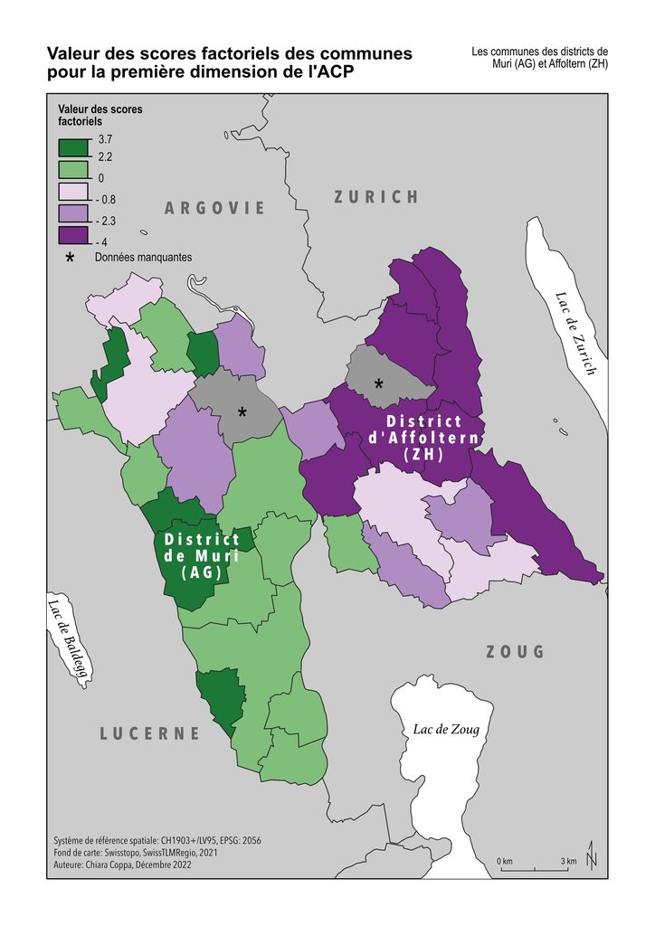

Ensuite, les scores factoriels de la deuxième composante me donnent la carte suivante:

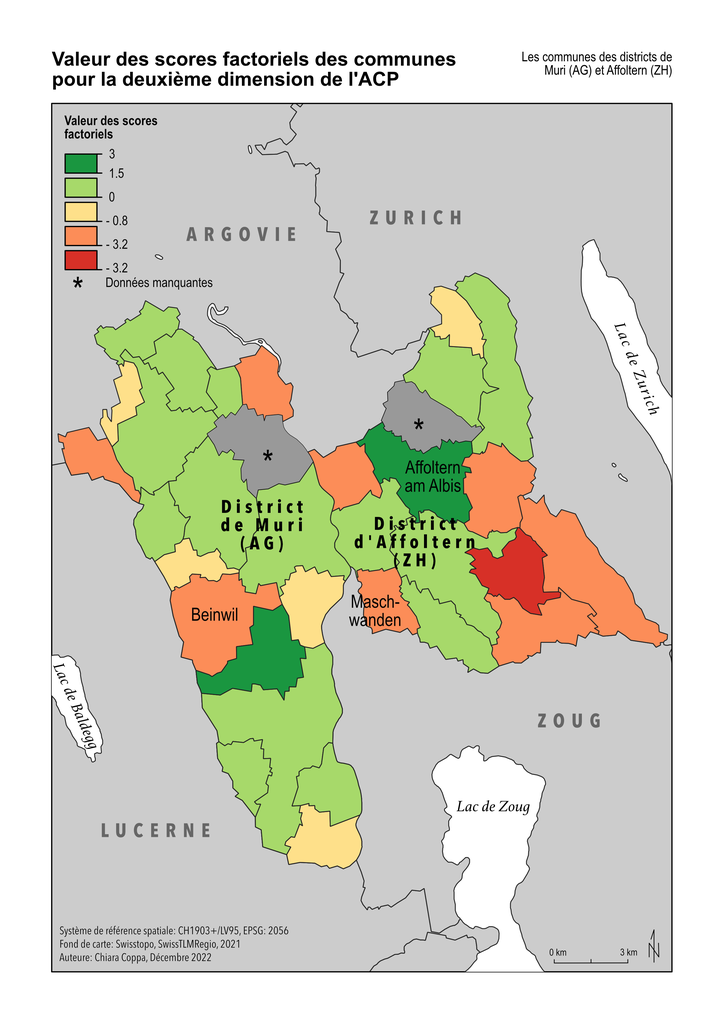

La deuxième composante, étant représentée en majorité par la proportion de population entre 20 et 39 ans est moins visible spatialement. On peut quand même remarquer que dans la commune plus urbaine de ma région, Affoltern am Albis, l’importance de la population entre 20 et 39 ans est significative. Au contraire dans deux communes plus rurales, comme ceux de Beinwil et Maschwanden, la proportion de population entre 20 et 39 ans est plus faible. Comme expliqué par l’analyse statistique des villes de 2018, réalisé par l’Office fédérale de la statistique suisse, dans les villes plus grandes, le pourcentage majeur de population est entre 20 et 39 ans.

Pour les autres composantes, la visualisation spatiale n’aide pas à l’interprétation de leur signification, mais les histogrammes de la contribution des variables aux composantes étaient assez significatifs.

# Conclusion

Au cours de cette analyse, j’ai condensé l’information de 17 variables initiales en quatre composantes principales, qui sont corrélées aux autres indicateurs et qui décrivent l’ensemble de la région sans avoir une grande perte d’informations. Les quatre composantes que j’ai gardées, je les ai interprétées en fonction de la contribution de chaque variable aux composantes et à l’aide aussi de la cartographie. Ces composantes sont donc, en ordre d’importance, la proportion de la surface agricole, la proportion de population entre 20 et 39 ans, la proportion de foyer d’une seule personne et la proportion de population de plus de 65 ans.

# Sources

Office fédéral de la statistique. (2018, avril 17). La population urbaine sous la loupe—Statistiques des villes suisses 2018 | Communiqué de presse. Office fédéral de la statistique. https://www.bfs.admin.ch/asset/fr/4942953